# R Final Project

Prasun Shrestha

December 9, 2019

Project Collaborators: Ajay Valecha and Premkumar Loganathan

Income inequality across genders is a pernicious issue in the United States. From the national soccer team to C-suites, the quest for equality perseveres. Many sources have cited various statistics, such as the wage discrepancy for the same job or the gendered patterns of industries, to address the inequality. Therefore, here is the underlying question: Is there a significant difference in income between men and women? If yes, what factors drive the difference?

The National Longitudinal Survey of Youth, 1979 cohort (NLSY79) data set is a rich source to answer the question. The NLSY79 data set contains survey responses on thousands of individuals who have been surveyed every one or two years starting in 1979, all the way to 2012. Respondents were 14 years old when surveyed in 1979, and the dataset has 12686 observations before cleaning.

This project addresses the questions above, analyzing the NLSY79 dataset. It presents statistical evidence to explore the income difference across genders and their driving factors. Following is the structure of the project:

1. Importing the Dataset
2. Variables Considered for Analysis and Rationale
3. Data Cleaning and Imputation
4. Recoding Factors
5. Exploratory Analysis of the Variables
6. Regression Analysis
7. Findings & Conclusion

## 1. Importing the Dataset

The NLSY79 dataset was imported with a pre-selected 70 variables to the data frame `nlsy`.

| gender | avg.income | sd.income |
| --- | --- | --- |
| 1 | 28436 | 57197 |
| 2 | 17003 | 30524 |

The p-value (<<<0.01) of the results of t-test suggests that the difference is statistically significant even at 0.001 level. The numbers here should be treated with caution, though, as the income variable is not cleaned yet. Because of the nature of the input, it contains negative values as well. The difference here, however, gives us an idea.

```
##
##  Welch Two Sample t-test
##
## data:  income by gender
## t = 14.082, df = 9814.9, p-value < 2.2e-16
## alternative hypothesis: true difference in means is not equal to 0
## 95 percent confidence interval:
##   9841.73 13024.83
## sample estimates:
## mean in group 1 mean in group 2
##        28435.99        17002.71
```

## 2. Variables Considered for Analysis and Rationale

What variables might explain the above mentioned income difference in men and women? The project considers the following seven variables (four categorical, three continuous) to analyze the difference. Time relevancy was a major reason to select the variables, and the rationale below further explain the rationale. The years in the bracket mention the survey year of the variable.

1. Race (1979): As with gender, income inequality also intersects with minority groups. As a result, the results, unfortunately, might be different for individuals in double jeopardy, such as black woman.
2. Years of Education (2012): Education is reasonably an important predictor of income. Thus, the variable here not only explains the change in income but it also explains the income difference in men and women once we control for years of education.
3. Urban/Rural (2012): An interesting analysis will be compare if (or how) income difference plays in different geographical setting. The idea here is also to understand the gender income gap once we account for the place of residence.
4. Family Size (2012): An increase in family size might increase inelasticity among the men for a higher income. A large family, on the other hand, might push women to household roles, perpetuating the income difference.
5. No. of previous jobs (2012): Generally, a higher number of jobs signify that the individual has low-paying jobs. The project analyzes if there are gendered patterns in the number of jobs.
6. Women’s place in the house (1979): Family attitude towards the women’s role in the house is a significant factor to a woman’s life opportunities. For example, a patriarchic household might limit women’s opportunity to education or employment, which, as a result, exacerbets the income difference. The survey year is appropriate as well because as the respondents were 14 years of age in 1979, family attitudes on gender then would have capacitated (or hindered) their life choices.
7. Industry (2012): A common counterargument to “justify” income difference is the industry. Many claim that men work at industries that are financially lucrative, such as finance and managerial positions, which explain the difference. If we were to control the industry, will the income difference persist? In other words, do male professors earn more than female professors? Same could be said for male doctor versus female doctor.

## 3. Data Cleaning and Imputation

As with any dataset, no dataset is originally clean. Missing data, inconsistent values, and unintuitive values of data arise often in any rigorous statistical analysis. Missing and inconsistent values are labeled as negative in this dataset. The imputation for the missing values for this anlaysis depended on their frequency and significance on a case-by-case basis. Whenever imputed, the mechanism used was Simple Random Imputation.

The function was derived from a chapter of the book “Data Analysis Using Regression and Multilevel/Hierarchical Models”. [Here](http://www.stat.columbia.edu/~gelman/arm/missing.pdf) is the link to the chapter.

Here is how the data were cleaned for all the variables:

Income: The observations with income less than 0 mean that they either refused to answer, did not know their income, invalidly (or validly) skipped the question, or did not respond the survey altogether. All the values that are less than 0 are set to NA, and the NAs are omitted. We cannot impute any values here because it’s the variable we are trying to predict. Plus it’s a continuous variable, so imputation hold any meaning.

As a result, the dataset is reduced to 7024 observations.

Gender, Race, & Family Size:: Both gender, race, and family size variables had no missing values, so they did not need to be cleaned. Unlike gender and race, family size is a continuous variable here.

Years of Education: The continuous variable used here is the highest grade completed. After the non-interviewees were removed, the years of education is clean as well with no missing or negative values.

Industry: The original coded industry variable was grouped into the categories mentioned in the data dictionary. Originally, the variable was assigned a factor, and the factor was later recoded into an intuitive name. Because of the frequency of the valid skip category (622), it was kept as its own category “Missing.” However, the uncodeable observations were assigned of the categories as the frequency was only 37. The random assignment still is better than deleting the entire row.

Urban/Rural: There were 60 missing observations that had valid skips. They were imputed to one of the values. The idea here again is to preserve the dataset whenever possible. The dataset is clean otherwise.

Women’s Role in the House (1979): The variable had around 1% of the total dataset that had irrelevant values - Don’t Know or Invalid Skip. Nonetheless, the values were imputed because although the random assignment here might not add any value, because the impute function was already established, it was fairly easy to apply the function.

Number of Jobs: As with years of education, after the non-interviewees were removed, the dataset is clean as well.

## 4. Recoding Factors

The categorical variables (gender, race, industry, urban_rural, womens_role_1979) were recoded to give intuitive names.

## 5. Exploratory Analysis of the Variables

#### 1. Income, Gender, and Race

| race | inc.diff | lower | upper | is.signif |
| --- | --- | --- | --- | --- |
| Other | 35542.667 | 31312.609 | 39772.72 | 1 |
| Black | 8683.128 | 5489.032 | 11877.22 | 1 |
| Hispanic | 18190.173 | 12939.252 | 23441.09 | 1 |

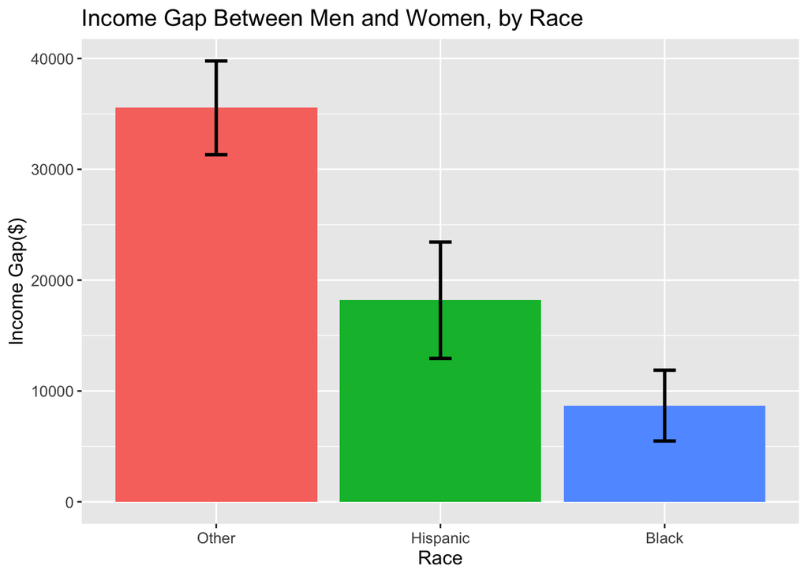

The income gap table tells us that the income difference is statistically significant across all genders, as pronounced by `is.signif` table, which returns to 1 if statistically significant, 0 otherwise. Furthermore, the bar plot in income gap by race shows us that the difference is different across all races. `Other` race have the highest average income gap, with `Hispanic` in the middle, and `Black` race having the lowest income gap. Interestingly, the error bar and the confidence interval from the income gap table also demonstrate that the difference in income gap across races is statistically significant. In other words, a hispanic woman will have a different experience in terms of income than a black woman when compared with their respective racial counterparts.

#### 2. Income, Gender, and Urban/Rural Setting

| urban_rural | inc.diff | lower | upper | is.signif |
| --- | --- | --- | --- | --- |
| Rural | 20447.75 | 15571.981 | 25323.52 | 1 |
| Urban | 24980.09 | 21919.041 | 28041.14 | 1 |
| Unknown | 15887.57 | 1676.733 | 30098.41 | 1 |

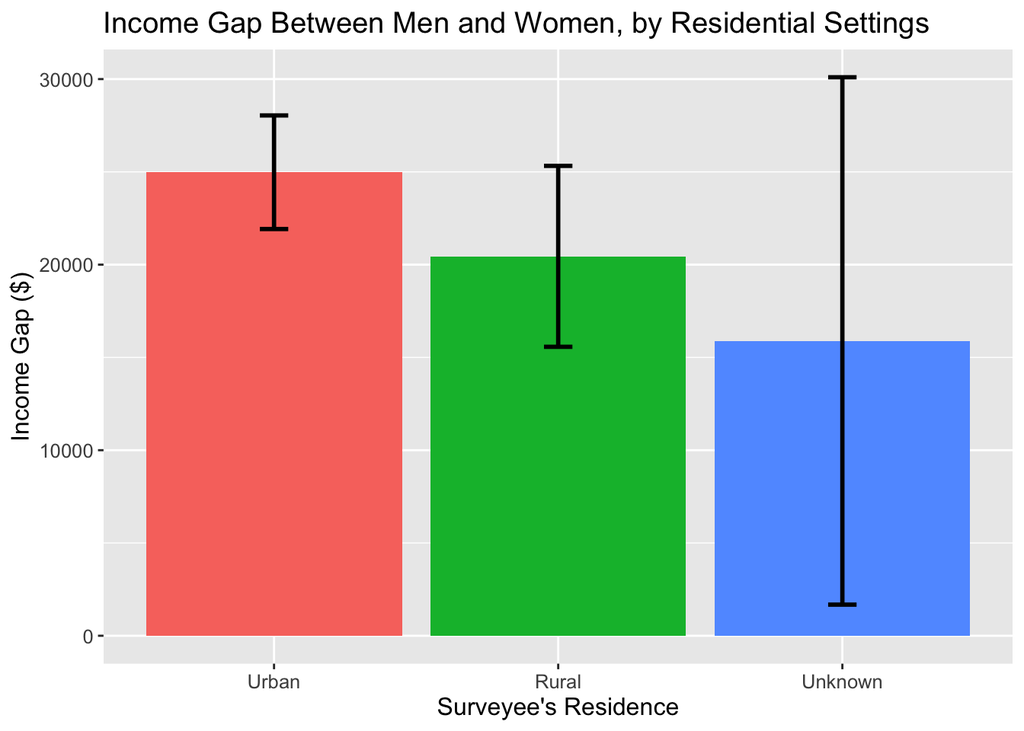

As depicted by the bar plot, the income difference across gender continues to prevail in both urban and rural settings. And the difference is statistically significant as well (also shown by `is.signif` column in the income gap table). Claims are often made that the urban areas because of higher economic opportunities tend to be an income equalizer. The plot here clearly shows otherwise.

That said, we cannot make any statistical claims that the income gap is significantly higher in urban than in rural settings. On the other hand, although the income gap in the `Unknown` category is statistically significant (as the error bars are above 0), the difference seem to fluctuate substantially. It makes sense because the category does not capture any specific residential setting.

### 3. Income, Gender, and Family Attitudes

| womens_role_1979 | inc.diff | lower | upper | is.signif |
| --- | --- | --- | --- | --- |
| Strongly Disagree | 29963.95 | 22718.45 | 37209.44 | 1 |
| Disagree | 26906.18 | 23347.95 | 30464.41 | 1 |
| Agree | 26388.72 | 20450.74 | 32326.70 | 1 |
| Strongly Agree | 19225.77 | 12138.04 | 26313.51 | 1 |

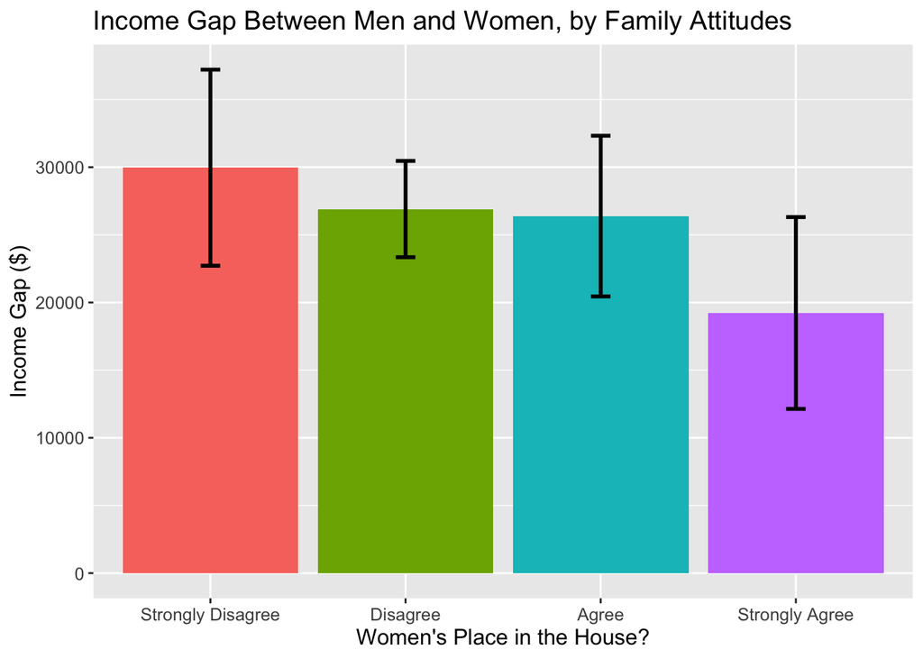

| womens_role_1979 | gender | avg.inc |
| --- | --- | --- |
| Strongly Disagree | Male | 64268.62 |
| Strongly Disagree | Female | 34304.67 |
| Disagree | Male | 55394.14 |
| Disagree | Female | 28487.96 |
| Agree | Male | 48768.99 |
| Agree | Female | 22380.27 |
| Strongly Agree | Male | 35892.95 |
| Strongly Agree | Female | 16667.18 |

The results here are counterintuitive and contrary to the original hypothesis. Regardless of the beliefs in whether a woman’s place is in the house, the gender income gap is statistically significant in all cases (`is.signif` column or the error bars above 0). More surprisingly, people who strongly disagree that a women’s place is in the house are indeed the ones who have the highest income gap on average.

On the other hand, people who strongly agree that a woman should be in the house in fact have the lowest income gap. None of the categories, in addition, are statistically significant from each other. Therefore, we cannot make any statistical claims a certain belief on whether a woman’s place is in the house is not linked to any lower or higher change in income gap.

A possible explanation to the counterintuitive results could be the confounding variables, such as occupation or the industry. In the table that mentions the average income across and family’s attitude, those who strongly disagree are also the ones who have the highest average income. Chances are they work in a financially rewarding industry or have occupations which have substantial income gap to begin with. The opposite is true for people who strongly agree. Because of their low average income, we can infer that the nature of the job might be blue collar and that the income gap in that industry is low. Thus, there is a potential selection bias in our observations, which could skew our intuition.

### 4. Income, Gender, and Industry

| industry | inc.diff | lower | upper | is.signif |
| --- | --- | --- | --- | --- |
| Agricultural and Forestry | 22755.783 | 7274.905 | 38236.66 | 1 |
| Mining | 11720.490 | -55172.618 | 78613.60 | 0 |
| Utilities | 27141.429 | -1414.533 | 55697.39 | 0 |
| Construction | 2732.064 | -7492.628 | 12956.76 | 0 |
| Manufacturing | 28245.891 | 20697.875 | 35793.91 | 1 |
| Wholesale Trade | 26856.228 | 7986.669 | 45725.79 | 1 |
| Retail Trade | 27557.389 | 18992.866 | 36121.91 | 1 |
| Transportation & Warehousing | 11914.350 | 1891.318 | 21937.38 | 1 |
| Information | 47801.609 | 27753.446 | 67849.77 | 1 |
| Finance & Insurance | 88358.410 | 62241.124 | 114475.70 | 1 |
| Real Estate, Rental, & Leasing | -2972.736 | -25421.144 | 19475.67 | 0 |
| Professional, Sci., & Tech Services | 66960.725 | 46632.620 | 87288.83 | 1 |
| Mgmt., Admin., & Waste Mgmt. | 7635.615 | -1417.600 | 16688.83 | 0 |
| Educational Services | 19450.576 | 10390.357 | 28510.79 | 1 |
| Health Care & Social Assistance | 40570.455 | 26576.259 | 54564.65 | 1 |
| Arts & Entertainment | 9884.088 | -3689.501 | 23457.68 | 0 |
| Accomodations & Food Services | 21623.113 | 9179.066 | 34067.16 | 1 |
| Other Services (except Pub. Adm.) | 23290.021 | 13134.506 | 33445.54 | 1 |
| Pub. Adm. & Military | 21095.343 | 13421.487 | 28769.20 | 1 |
| Armed Forces | -5833.333 | -86178.764 | 74512.10 | 0 |
| Missing | 9421.109 | 3757.017 | 15085.20 | 1 |

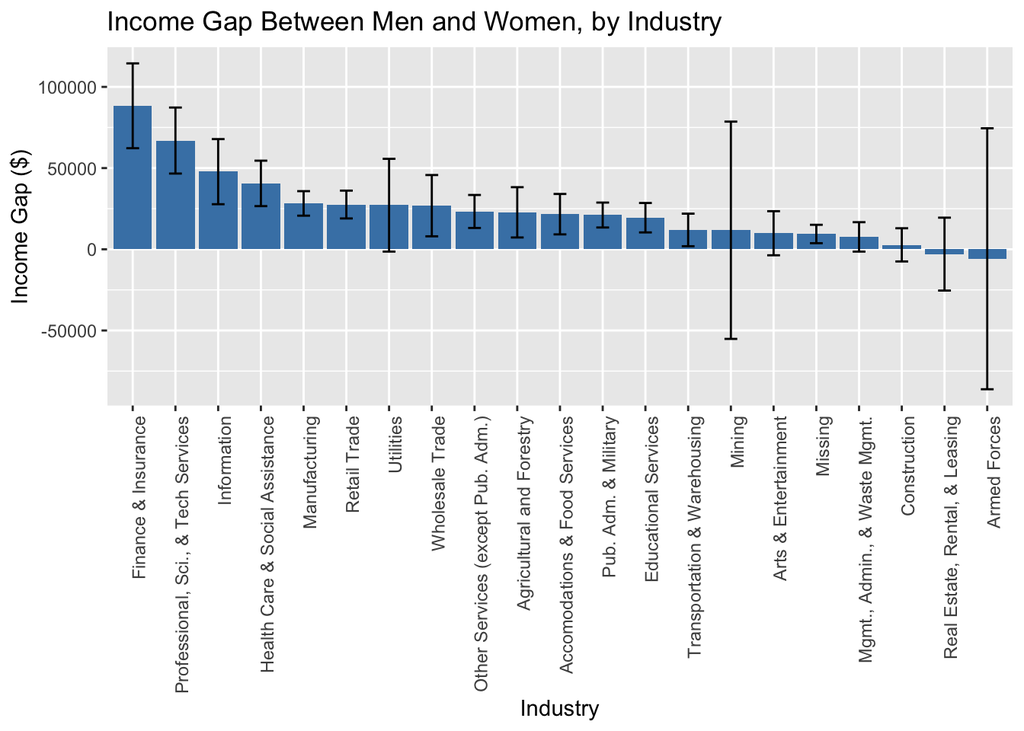

This is a myth buster. The financially-most rewarding industries have the highest income gap across gender, and the difference is statistically significant. The non-statistically significant industries are the ones that are labor intensive, such as construction, mining, and armed forces. As with the previous variables, the interpretation here is that the income gap persists even in the same industry. For example, a male financial anlayst might be earning significantly higher than a female financial analyst.

The interpretation can be extrapolated to most of the service sectors, such as education, health care, and public administration, as the income gap in all those sectors are statistically significant.

### 5. Income, Gender, and Years of Education

Also, the scatter plot tells us the upper end of the income for every educational year are males. And the overwhelming majority of the top coded income variables (top 2%) are males as well.

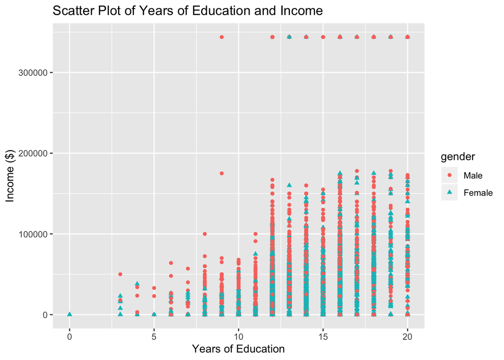

| edu_yrs | gender | avg.income |
| --- | --- | --- |
| 0 | Female | 0 |
| 3 | Male | 34000 |
| 3 | Female | 9257 |
| 4 | Male | 15175 |
| 4 | Female | 19000 |
| 5 | Male | 18667 |
| 5 | Female | 0 |
| 6 | Male | 21182 |
| 6 | Female | 4264 |
| 7 | Male | 10381 |
| 7 | Female | 5409 |
| 8 | Male | 15947 |
| 8 | Female | 4035 |
| 9 | Male | 21481 |
| 9 | Female | 7422 |
| 10 | Male | 15727 |
| 10 | Female | 6521 |
| 11 | Male | 17979 |
| 11 | Female | 10127 |
| 12 | Male | 35594 |
| 12 | Female | 20821 |
| 13 | Male | 50073 |
| 13 | Female | 27773 |
| 14 | Male | 52006 |
| 14 | Female | 30468 |
| 15 | Male | 60523 |
| 15 | Female | 28718 |
| 16 | Male | 99373 |
| 16 | Female | 47055 |
| 17 | Male | 87995 |
| 17 | Female | 47855 |
| 18 | Male | 126561 |
| 18 | Female | 53896 |
| 19 | Male | 124460 |
| 19 | Female | 70402 |
| 20 | Male | 165951 |
| 20 | Female | 72784 |

### 5. Income, Gender, and Family Size

[figure not shown]

## 5. Income, Gender, and Number of Jobs Previously Held

[figure not shown]

As expected, higher number of jobs previously held tend to associate with a lower income, as a single low-paying job might not suffice the living expenses. Much of the datapoints for female tend to be concentrated on the lower end. And the opposite is true for males. Essentially, a same number of jobs previously held is linked with higher income for males and relatively lower income for females. Likewise, the top 2% tend to have less than 20 jobs by 2012 because their job is likely demanding and time-consuming and a single job should more than enough to sustain their likelihood.

## 6. Regression

Each covariate here have been added on an forward selection basis, and the ANOVA table is used to check if the added variable is statistically significant.

REGRESSION 1: Income and Gender

```
##
## Call:
## lm(formula = income ~ gender, data = nlsy)
##
## Residuals:
##    Min     1Q Median     3Q    Max
## -53446 -29539 -11446  15147 314291
##
## Coefficients:
##              Estimate Std. Error t value Pr(>|t|)
## (Intercept)   53445.9      934.7   57.18   <2e-16 ***
## genderFemale -23907.4     1302.6  -18.35   <2e-16 ***
## ---
## Signif. codes:  0 '***' 0.001 '**' 0.01 '*' 0.05 '.' 0.1 ' ' 1
##
## Residual standard error: 54560 on 7022 degrees of freedom
## Multiple R-squared:  0.04578,    Adjusted R-squared:  0.04564
## F-statistic: 336.9 on 1 and 7022 DF,  p-value: < 2.2e-16
```

The basecase here is Male. Therefore, as the coefficient of the genderFemale suggests, on average, being female is associated with ~24k dollars less income as compared to males. The p-value of the coefficient confirms that it is statistically significant.

REGRESSION 2: Income and Gender + Race

```
##
## Call:
## lm(formula = income ~ gender + race, data = nlsy)
##
## Residuals:
##    Min     1Q Median     3Q    Max
## -63130 -29587 -11085  14870 318745
##
## Coefficients:
##              Estimate Std. Error t value Pr(>|t|)
## (Intercept)     63130       1120  56.344   <2e-16 ***
## genderFemale   -23906       1280 -18.671   <2e-16 ***
## raceBlack      -22543       1467 -15.370   <2e-16 ***
## raceHispanic   -14140       1713  -8.253   <2e-16 ***
## ---
## Signif. codes:  0 '***' 0.001 '**' 0.01 '*' 0.05 '.' 0.1 ' ' 1
##
## Residual standard error: 53630 on 7020 degrees of freedom
## Multiple R-squared:  0.07832,    Adjusted R-squared:  0.07793
## F-statistic: 198.8 on 3 and 7020 DF,  p-value: < 2.2e-16
```

All three predictors are statistically significant here.

```
## Analysis of Variance Table
##
## Model 1: income ~ gender
## Model 2: income ~ gender + race
##   Res.Df            RSS Df    Sum of Sq      F    Pr(>F)
## 1   7022 20903427347447
## 2   7020 20190464268874  2 712963078573 123.94 < 2.2e-16 ***
## ---
## Signif. codes:  0 '***' 0.001 '**' 0.01 '*' 0.05 '.' 0.1 ' ' 1
```

Race is a statistically significant predictor of income.

REGRESSION 3: Income and Gender + Race + Urban/Rural

```
##
## Call:
## lm(formula = income ~ gender + race + urban_rural, data = nlsy)
##
## Residuals:
##    Min     1Q Median     3Q    Max
## -67009 -29835 -10009  14894 317292
##
## Coefficients:
##                    Estimate Std. Error t value Pr(>|t|)
## (Intercept)         54560.2     1614.5  33.793  < 2e-16 ***
## genderFemale       -23870.3     1274.9 -18.723  < 2e-16 ***
## raceBlack          -24724.9     1486.7 -16.631  < 2e-16 ***
## raceHispanic       -16600.6     1736.3  -9.561  < 2e-16 ***
## urban_ruralUrban    12448.8     1641.2   7.585 3.74e-14 ***
## urban_ruralUnknown   -853.9     4739.2  -0.180    0.857
## ---
## Signif. codes:  0 '***' 0.001 '**' 0.01 '*' 0.05 '.' 0.1 ' ' 1
##
## Residual standard error: 53400 on 7018 degrees of freedom
## Multiple R-squared:  0.08652,    Adjusted R-squared:  0.08587
## F-statistic: 132.9 on 5 and 7018 DF,  p-value: < 2.2e-16
```

Urban areas constitute to a higher income on average holding everything else constant. The p-value is statistically significant as well. The coefficient for female is negative here, meaning the wage difference prevails even after accounting for the residential setting (urban vs. rural).

```
## Analysis of Variance Table
##
## Model 1: income ~ gender + race
## Model 2: income ~ gender + race + urban_rural
##   Res.Df            RSS Df    Sum of Sq      F    Pr(>F)
## 1   7020 20190464268874
## 2   7018 20010894705826  2 179569563049 31.488 2.431e-14 ***
## ---
## Signif. codes:  0 '***' 0.001 '**' 0.01 '*' 0.05 '.' 0.1 ' ' 1
```

Residential setting is a statistically significant predictor of income.

REGRESSION 4: Income and Gender + Race + Urban/Rural + Years of Education

```
##
## Call:
## lm(formula = income ~ gender + race + urban_rural + edu_yrs,
##     data = nlsy)
##
## Residuals:
##     Min      1Q  Median      3Q     Max
## -118212  -25214   -6458   15194  322799
##
## Coefficients:
##                    Estimate Std. Error t value  Pr(>|t|)
## (Intercept)        -55513.9     3432.6 -16.173   < 2e-16 ***
## genderFemale       -26546.3     1176.0 -22.574   < 2e-16 ***
## raceBlack          -17675.3     1382.8 -12.783   < 2e-16 ***
## raceHispanic        -5245.4     1629.8  -3.218    0.0013 **
## urban_ruralUrban     6242.4     1520.7   4.105 0.0000409 ***
## urban_ruralUnknown    917.5     4362.7   0.210    0.8334
## edu_yrs              8394.2      236.0  35.575   < 2e-16 ***
## ---
## Signif. codes:  0 '***' 0.001 '**' 0.01 '*' 0.05 '.' 0.1 ' ' 1
##
## Residual standard error: 49150 on 7017 degrees of freedom
## Multiple R-squared:  0.2261, Adjusted R-squared:  0.2254
## F-statistic: 341.7 on 6 and 7017 DF,  p-value: < 2.2e-16
```

An additional year of education is linked with an additional ~$8400 income. Expectedly, the coefficient of years of education is statistically significant here as well. Unfortunately, females with same years of education as their male counterparts receive lower income (still negative statistically significant coefficient on genderFemale).

```
## Analysis of Variance Table
##
## Model 1: income ~ gender + race + urban_rural
## Model 2: income ~ gender + race + urban_rural + edu_yrs
##   Res.Df            RSS Df     Sum of Sq      F    Pr(>F)
## 1   7018 20010894705826
## 2   7017 16953287135927  1 3057607569899 1265.5 < 2.2e-16 ***
## ---
## Signif. codes:  0 '***' 0.001 '**' 0.01 '*' 0.05 '.' 0.1 ' ' 1
```

Years of education is a statistically significant predictor of income.

REGRESSION 5: Income and Gender + Race + Urban/Rural + Years of Education + Family Size

```
##
## Call:
## lm(formula = income ~ gender + race + urban_rural + edu_yrs +
##     famsize, data = nlsy)
##
## Residuals:
##     Min      1Q  Median      3Q     Max
## -118634  -25726   -6067   15353  326874
##
## Coefficients:
##                    Estimate Std. Error t value Pr(>|t|)
## (Intercept)        -60303.0     3518.3 -17.140  < 2e-16 ***
## genderFemale       -26850.3     1174.2 -22.866  < 2e-16 ***
## raceBlack          -17334.0     1380.6 -12.555  < 2e-16 ***
## raceHispanic        -5965.5     1630.4  -3.659 0.000255 ***
## urban_ruralUrban     6151.1     1517.1   4.054 5.08e-05 ***
## urban_ruralUnknown   1113.5     4352.2   0.256 0.798071
## edu_yrs              8290.8      236.0  35.125  < 2e-16 ***
## famsize              2457.0      414.6   5.927 3.24e-09 ***
## ---
## Signif. codes:  0 '***' 0.001 '**' 0.01 '*' 0.05 '.' 0.1 ' ' 1
##
## Residual standard error: 49030 on 7016 degrees of freedom
## Multiple R-squared:   0.23,  Adjusted R-squared:  0.2292
## F-statistic: 299.3 on 7 and 7016 DF,  p-value: < 2.2e-16
```

A higher family size is associated with a higher income, holding everything else constant.

```
## Analysis of Variance Table
##
## Model 1: income ~ gender + race + urban_rural + edu_yrs
## Model 2: income ~ gender + race + urban_rural + edu_yrs + famsize
##   Res.Df            RSS Df   Sum of Sq      F    Pr(>F)
## 1   7017 16953287135927
## 2   7016 16868833853256  1 84453282671 35.125 3.238e-09 ***
## ---
## Signif. codes:  0 '***' 0.001 '**' 0.01 '*' 0.05 '.' 0.1 ' ' 1
```

Family size is a statistically significant predictor of income.

REGRESSION 6: Income and Gender + Race + Urban/Rural + Years of Education + Family Size + No. of Previous Jobs

```
##
## Call:
## lm(formula = income ~ gender + race + urban_rural + edu_yrs +
##     famsize + jobsnum_2012, data = nlsy)
##
## Residuals:
##     Min      1Q  Median      3Q     Max
## -122489  -25623   -5903   15027  321688
##
## Coefficients:
##                     Estimate Std. Error t value   Pr(>|t|)
## (Intercept)        -50643.46    3604.58 -14.050    < 2e-16 ***
## genderFemale       -28050.60    1170.18 -23.971    < 2e-16 ***
## raceBlack          -17858.63    1370.42 -13.032    < 2e-16 ***
## raceHispanic        -6341.97    1617.74  -3.920 0.00008929 ***
## urban_ruralUrban     7006.78    1507.09   4.649 0.00000339 ***
## urban_ruralUnknown   2433.26    4319.09   0.563      0.573
## edu_yrs              8484.87     234.84  36.130    < 2e-16 ***
## famsize              2009.70     413.36   4.862 0.00000119 ***
## jobsnum_2012         -893.24      83.33 -10.719    < 2e-16 ***
## ---
## Signif. codes:  0 '***' 0.001 '**' 0.01 '*' 0.05 '.' 0.1 ' ' 1
##
## Residual standard error: 48640 on 7015 degrees of freedom
## Multiple R-squared:  0.2424, Adjusted R-squared:  0.2415
## F-statistic: 280.5 on 8 and 7015 DF,  p-value: < 2.2e-16
```

```
## Analysis of Variance Table
##
## Model 1: income ~ gender + race + urban_rural + edu_yrs + famsize
## Model 2: income ~ gender + race + urban_rural + edu_yrs + famsize + jobsnum_2012
##   Res.Df            RSS Df    Sum of Sq      F    Pr(>F)
## 1   7016 16868833853256
## 2   7015 16597004427345  1 271829425910 114.89 < 2.2e-16 ***
## ---
## Signif. codes:  0 '***' 0.001 '**' 0.01 '*' 0.05 '.' 0.1 ' ' 1
```

REGRESSION 7: Income and Gender + Race + Urban/Rural + Years of Education + Family Size + No. of Previous Jobs + Industry

```
##
## Call:
## lm(formula = income ~ gender + race + urban_rural + edu_yrs +
##     famsize + jobsnum_2012 + industry, data = nlsy)
##
## Residuals:
##     Min      1Q  Median      3Q     Max
## -140468  -23432   -4920   14072  323308
##
## Coefficients:
##                                              Estimate Std. Error t value
## (Intercept)                                 -50900.96    6398.32  -7.955
## genderFemale                                -27103.60    1238.96 -21.876
## raceBlack                                   -16196.40    1343.61 -12.054
## raceHispanic                                 -5987.98    1577.16  -3.797
## urban_ruralUrban                              5810.54    1474.26   3.941
## urban_ruralUnknown                            3244.55    4195.76   0.773
## edu_yrs                                       7793.13     244.31  31.899
## famsize                                       2048.56     401.29   5.105
## jobsnum_2012                                  -928.71      83.03 -11.185
## industryMining                               31932.13    9575.61   3.335
## industryUtilities                            33800.22    7802.24   4.332
## industryConstruction                          1407.04    5886.80   0.239
## industryManufacturing                        16859.73    5736.48   2.939
## industryWholesale Trade                      24188.24    6547.84   3.694
## industryRetail Trade                          4606.62    5846.07   0.788
## industryTransportation & Warehousing         18802.64    5992.06   3.138
## industryInformation                          19081.58    6832.99   2.793
## industryFinance & Insurance                  37828.68    6243.19   6.059
## industryReal Estate, Rental, & Leasing        7877.28    7093.36   1.111
## industryProfessional, Sci., & Tech Services  33746.87    6179.01   5.462
## industryMgmt., Admin., & Waste Mgmt.          1867.42    5992.46   0.312
## industryEducational Services                   362.50    5884.25   0.062
## industryHealth Care & Social Assistance      12984.18    5747.27   2.259
## industryArts & Entertainment                 -3333.65    7262.57  -0.459
## industryAccomodations & Food Services         3670.09    6163.60   0.595
## industryOther Services (except Pub. Adm.)     1935.53    6092.00   0.318
## industryPub. Adm. & Military                 16356.54    5967.33   2.741
## industryArmed Forces                         -5740.08   15248.24  -0.376
## industryMissing                             -13144.79    5825.45  -2.256
```

[output cut: 21 more lines]

```
## industryMgmt., Admin., & Waste Mgmt.        0.755332
## industryEducational Services                0.950879
## industryHealth Care & Social Assistance     0.023902 *
## industryArts & Entertainment                0.646235
## industryAccomodations & Food Services       0.551565
## industryOther Services (except Pub. Adm.)   0.750710
## industryPub. Adm. & Military                0.006141 **
## industryArmed Forces                        0.706600
## industryMissing                             0.024074 *
## ---
## Signif. codes:  0 '***' 0.001 '**' 0.01 '*' 0.05 '.' 0.1 ' ' 1
##
## Residual standard error: 47140 on 6995 degrees of freedom
## Multiple R-squared:  0.2906, Adjusted R-squared:  0.2877
## F-statistic: 102.3 on 28 and 6995 DF,  p-value: < 2.2e-16
```

```
## Analysis of Variance Table
##
## Model 1: income ~ gender + race + urban_rural + edu_yrs + famsize + jobsnum_2012
## Model 2: income ~ gender + race + urban_rural + edu_yrs + famsize + jobsnum_2012 +
##     industry
##   Res.Df            RSS Df     Sum of Sq     F    Pr(>F)
## 1   7015 16597004427345
## 2   6995 15541215156720 20 1055789270626 23.76 < 2.2e-16 ***
## ---
## Signif. codes:  0 '***' 0.001 '**' 0.01 '*' 0.05 '.' 0.1 ' ' 1
```

REGRESSION 8: Income and Gender + Race + Urban/Rural + Years of Education + Family Size + No. of Previous Jobs + Industry + Family’s Attitude

```
##
## Call:
## lm(formula = income ~ gender + race + urban_rural + edu_yrs +
##     famsize + industry + jobsnum_2012 + womens_role_1979, data = nlsy)
##
## Residuals:
##     Min      1Q  Median      3Q     Max
## -140726  -23428   -4950   14094  323055
##
## Coefficients:
##                                              Estimate Std. Error t value
## (Intercept)                                 -49189.25    6707.69  -7.333
## genderFemale                                -27348.54    1287.45 -21.242
## raceBlack                                   -16196.73    1345.64 -12.036
## raceHispanic                                 -5949.61    1579.04  -3.768
## urban_ruralUrban                              5751.82    1475.89   3.897
## urban_ruralUnknown                            3166.62    4197.75   0.754
## edu_yrs                                       7746.80     250.11  30.974
## famsize                                       2050.45     401.40   5.108
## industryMining                               31731.68    9588.17   3.309
## industryUtilities                            33557.64    7810.87   4.296
## industryConstruction                          1182.35    5893.25   0.201
## industryManufacturing                        16670.33    5743.85   2.902
## industryWholesale Trade                      24137.56    6556.01   3.682
## industryRetail Trade                          4399.92    5852.75   0.752
## industryTransportation & Warehousing         18590.40    6001.19   3.098
## industryInformation                          18795.53    6838.54   2.748
## industryFinance & Insurance                  37617.03    6251.16   6.018
## industryReal Estate, Rental, & Leasing        7599.98    7099.01   1.071
## industryProfessional, Sci., & Tech Services  33556.57    6188.48   5.422
## industryMgmt., Admin., & Waste Mgmt.          1698.87    5999.22   0.283
## industryEducational Services                   181.02    5889.51   0.031
## industryHealth Care & Social Assistance      12804.85    5754.19   2.225
## industryArts & Entertainment                 -3461.96    7271.53  -0.476
## industryAccomodations & Food Services         3541.51    6168.68   0.574
## industryOther Services (except Pub. Adm.)     1798.31    6098.49   0.295
## industryPub. Adm. & Military                 16145.47    5976.07   2.702
## industryArmed Forces                         -6001.50   15255.65  -0.393
## industryMissing                             -13265.22    5829.99  -2.275
## jobsnum_2012                                  -932.37      83.16 -11.212
```

[output cut: 27 more lines]

```
## industryAccomodations & Food Services       0.565911
## industryOther Services (except Pub. Adm.)   0.768096
## industryPub. Adm. & Military                0.006916 **
## industryArmed Forces                        0.694040
## industryMissing                             0.022916 *
## jobsnum_2012                                 < 2e-16 ***
## womens_role_1979Disagree                    0.517353
## womens_role_1979Agree                       0.866977
## womens_role_1979Strongly Agree              0.205550
## ---
## Signif. codes:  0 '***' 0.001 '**' 0.01 '*' 0.05 '.' 0.1 ' ' 1
##
## Residual standard error: 47140 on 6992 degrees of freedom
## Multiple R-squared:  0.2907, Adjusted R-squared:  0.2876
## F-statistic: 92.46 on 31 and 6992 DF,  p-value: < 2.2e-16
```

```
## Analysis of Variance Table
##
## Model 1: income ~ gender + race + urban_rural + edu_yrs + famsize + industry +
##     jobsnum_2012
## Model 2: income ~ gender + race + urban_rural + edu_yrs + famsize + industry +
##     jobsnum_2012 + womens_role_1979
##   Res.Df            RSS Df  Sum of Sq      F Pr(>F)
## 1   6995 15541215156720
## 2   6992 15537252383267  3 3962773453 0.5944 0.6186
```

### FINAL REGRESSION (including interaction term)

```
##
## Call:
## lm(formula = income ~ gender * industry + race + urban_rural +
##     edu_yrs + famsize + jobsnum_2012 + womens_role_1979, data = nlsy)
##
## Residuals:
##     Min      1Q  Median      3Q     Max
## -151994  -22949   -4932   14047  321260
##
## Coefficients:
##                                                           Estimate
## (Intercept)                                              -47601.66
## genderFemale                                             -21229.97
## industryMining                                            33328.37
## industryUtilities                                         37352.67
## industryConstruction                                        881.55
## industryManufacturing                                     17487.22
## industryWholesale Trade                                   26138.53
## industryRetail Trade                                       5415.00
## industryTransportation & Warehousing                      18154.66
## industryInformation                                       29176.52
## industryFinance & Insurance                               71413.01
## industryReal Estate, Rental, & Leasing                      815.42
## industryProfessional, Sci., & Tech Services               48036.99
## industryMgmt., Admin., & Waste Mgmt.                      -2412.74
## industryEducational Services                              -3046.21
## industryHealth Care & Social Assistance                   20810.36
## industryArts & Entertainment                              -2042.21
## industryAccomodations & Food Services                       741.13
## industryOther Services (except Pub. Adm.)                  4304.70
## industryPub. Adm. & Military                              12648.63
## industryArmed Forces                                      -4983.34
## industryMissing                                          -17740.69
## raceBlack                                                -15674.62
## raceHispanic                                              -5534.18
## urban_ruralUrban                                           5723.49
## urban_ruralUnknown                                         3345.38
## edu_yrs                                                    7504.54
## famsize                                                    1952.44
## jobsnum_2012                                               -901.68
```

[output cut: 173 more lines]

```
## genderFemale:industryMgmt., Admin., & Waste Mgmt.
## genderFemale:industryEducational Services
## genderFemale:industryHealth Care & Social Assistance
## genderFemale:industryArts & Entertainment
## genderFemale:industryAccomodations & Food Services
## genderFemale:industryOther Services (except Pub. Adm.)
## genderFemale:industryPub. Adm. & Military
## genderFemale:industryArmed Forces
## genderFemale:industryMissing
## ---
## Signif. codes:  0 '***' 0.001 '**' 0.01 '*' 0.05 '.' 0.1 ' ' 1
##
## Residual standard error: 46800 on 6972 degrees of freedom
## Multiple R-squared:  0.303,  Adjusted R-squared:  0.2979
## F-statistic: 59.43 on 51 and 6972 DF,  p-value: < 2.2e-16
```

There are some interactions, such as genderFemale:industryFinance & Insurance, that are statistically significant, which suggest that the income gap is different across different industries. The coefficient could be interpreted as follows after the addition of the interaction term:

```
## Analysis of Variance Table
##
## Model 1: income ~ gender + race + urban_rural + edu_yrs + famsize + industry +
##     jobsnum_2012 + womens_role_1979
## Model 2: income ~ gender * industry + race + urban_rural + edu_yrs + famsize +
##     jobsnum_2012 + womens_role_1979
##   Res.Df            RSS Df    Sum of Sq      F    Pr(>F)
## 1   6992 15537252383267
## 2   6972 15268448145166 20 268804238101 6.1372 < 2.2e-16 ***
## ---
## Signif. codes:  0 '***' 0.001 '**' 0.01 '*' 0.05 '.' 0.1 ' ' 1
```

The interaction term here is statistically significant.

Correlation Matrix among the independent variables

```
##             [,1]       [,2]        [,3]
## [1,]  1.00000000 0.07058762 -0.09822927
## [2,]  0.07058762 1.00000000  0.07465477
## [3,] -0.09822927 0.07465477  1.00000000
```

### Drawing the QQ-plot here to test the if the model is normally distributed

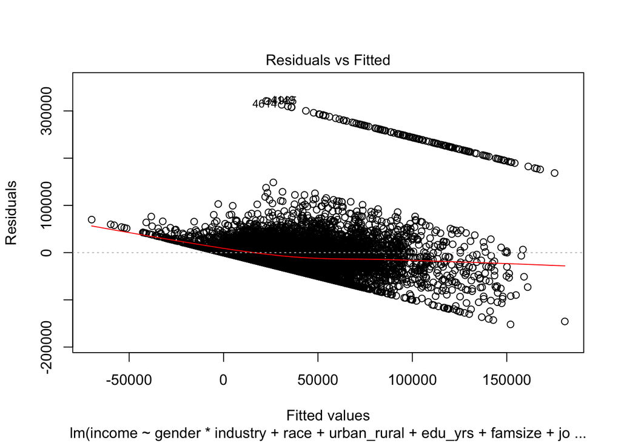

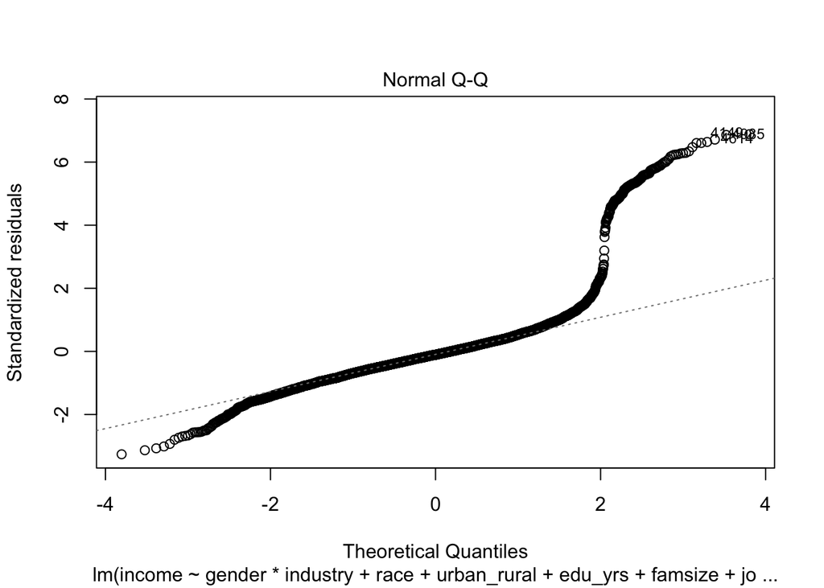

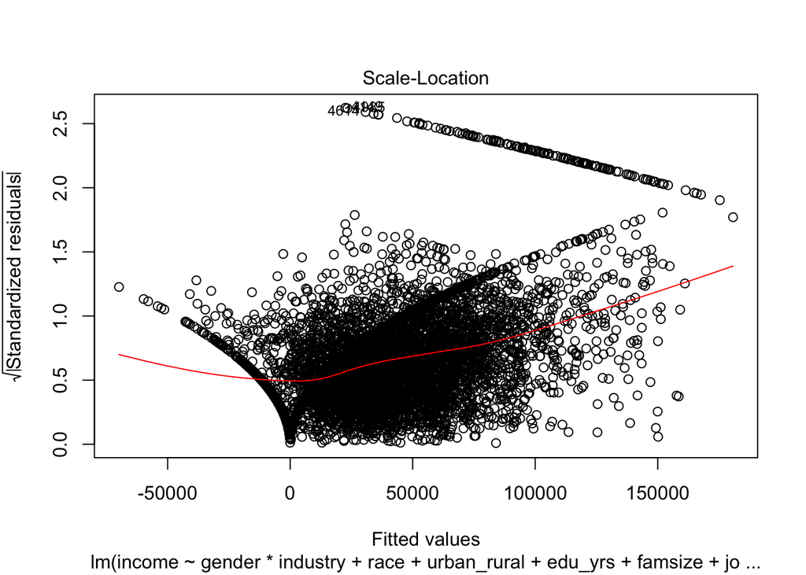

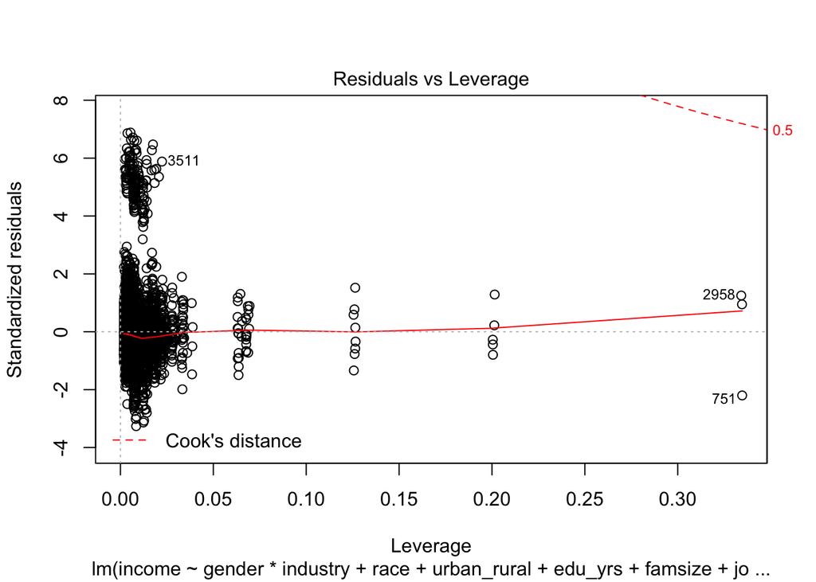

The top-coded values here seem to skew the standardized residuals as they are much higher than what the theoretical quantiles suggest. This is also evident in the skewed residuals in the residuals versus fitted values, which show that the variance of the residuals is not consistent with the fitted values and that the line of best fit is not horizontal. Therefore, the regresssion model is not linear.

### Removing the topcoded values

```
##
## Call:
## lm(formula = income ~ gender * industry + race + urban_rural +
##     edu_yrs + famsize + jobsnum_2012 + womens_role_1979, data = nlsy.trim)
##
## Residuals:
##    Min     1Q Median     3Q    Max
## -97420 -18098  -2702  14683 148481
##
## Coefficients:
##                                                           Estimate
## (Intercept)                                              -19649.39
## genderFemale                                             -16609.23
## industryMining                                            38868.90
## industryUtilities                                         31107.95
## industryConstruction                                       3274.25
## industryManufacturing                                     15542.44
## industryWholesale Trade                                   10537.60
## industryRetail Trade                                       2750.05
## industryTransportation & Warehousing                      14704.42
## industryInformation                                       23353.78
## industryFinance & Insurance                               24681.80
## industryReal Estate, Rental, & Leasing                    -2438.69
## industryProfessional, Sci., & Tech Services               24180.13
## industryMgmt., Admin., & Waste Mgmt.                      -4061.05
## industryEducational Services                               4385.85
## industryHealth Care & Social Assistance                    7062.65
## industryArts & Entertainment                               3437.24
## industryAccomodations & Food Services                     -6747.01
## industryOther Services (except Pub. Adm.)                  1982.55
## industryPub. Adm. & Military                              21166.65
## industryArmed Forces                                       3453.60
## industryMissing                                          -16476.74
## raceBlack                                                -10741.45
## raceHispanic                                              -3900.74
## urban_ruralUrban                                           3474.49
## urban_ruralUnknown                                         2745.24
## edu_yrs                                                    4832.17
## famsize                                                    1012.22
## jobsnum_2012                                               -646.93
```

[output cut: 173 more lines]

```
## genderFemale:industryMgmt., Admin., & Waste Mgmt.            0.425921
## genderFemale:industryEducational Services                    0.935641
## genderFemale:industryHealth Care & Social Assistance         0.757545
## genderFemale:industryArts & Entertainment                    0.618114
## genderFemale:industryAccomodations & Food Services           0.412502
## genderFemale:industryOther Services (except Pub. Adm.)       0.676122
## genderFemale:industryPub. Adm. & Military                    0.879263
## genderFemale:industryArmed Forces                            0.924533
## genderFemale:industryMissing                                 0.688573
## ---
## Signif. codes:  0 '***' 0.001 '**' 0.01 '*' 0.05 '.' 0.1 ' ' 1
##
## Residual standard error: 28910 on 6829 degrees of freedom
## Multiple R-squared:  0.3308, Adjusted R-squared:  0.3258
## F-statistic:  66.2 on 51 and 6829 DF,  p-value: < 2.2e-16
```

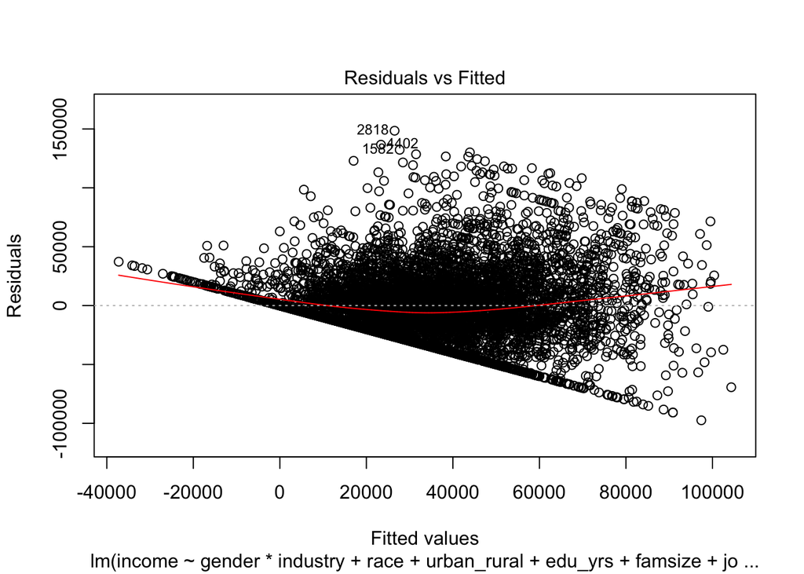

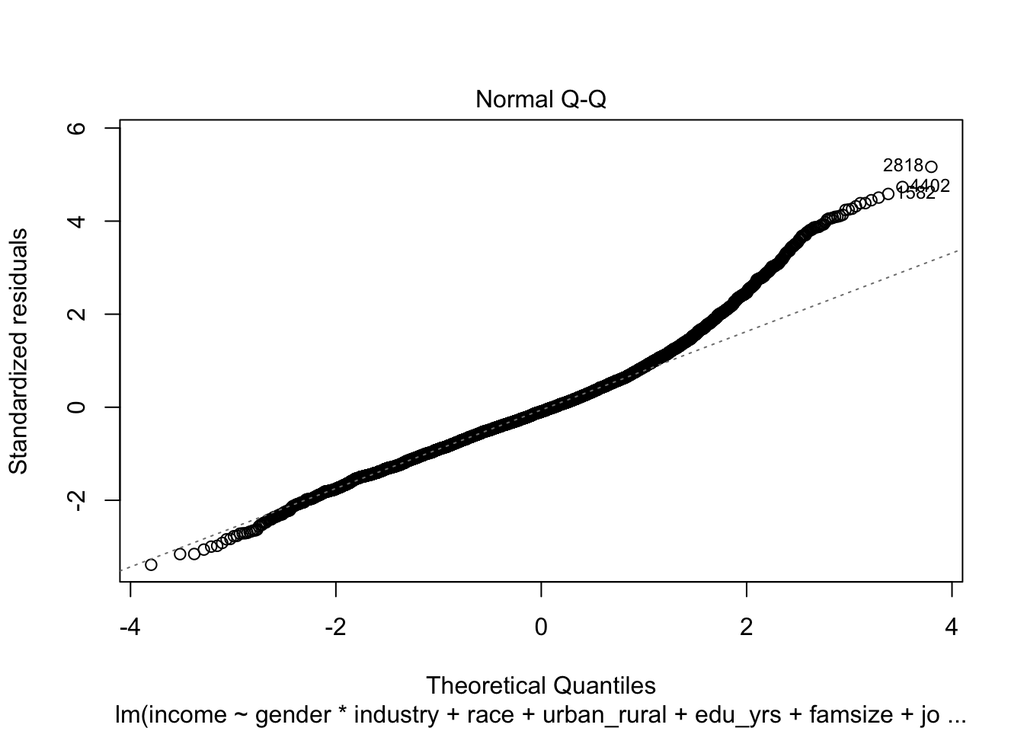

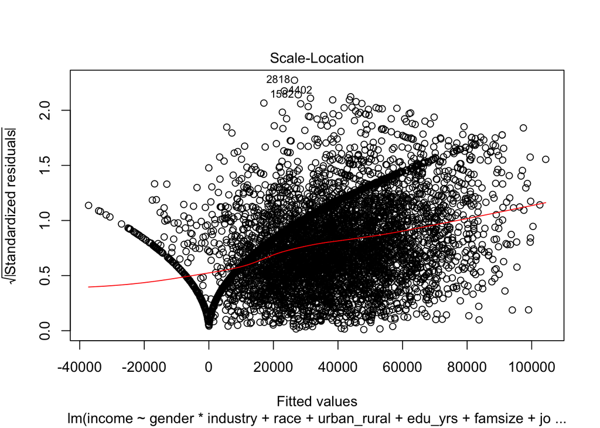

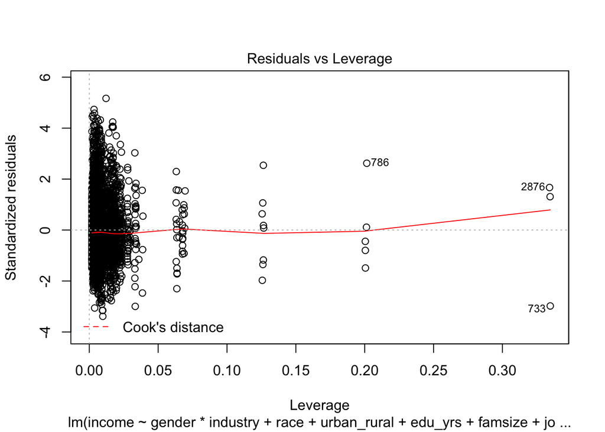

None of the interaction terms are statistically significant 0.05 level. If anything, genderFemale:industryInformation is statistically significant at 0.1 level. The QQ plot shows that the model now is much less skewed although the standardized residuals tend to increase with increasingly value of theoretical quantiles.

The residuals vs fitted plot indicates the variance of residuals has decreased with much of the data concentrating around the 0. The future model should exclude topcoded values, however, any of the findings will not be generalizable to the entire population.

### 7. Findings and Conclusion

The top 2% values of income seem to have skewed the results, however, after trimming the dataset and re-running the regression, no-interaction term were statistically significant surprisingly. There seem to a couple of confounding variables, such as paternal income, education degree, which explain for the income but was not included in the model. In the end, I will trust the model as an abundance of variables are statistically significant, however, I will treat the interpretation with caution.